# Mixed sensitivity design

In the previous chapter we mentioned that there are several ways to characterize the uncertainty in the model and analyze robustness with respect to the uncertainty. We have chosen the worst-case approach based on the *small gain theorem* for analysis of robust stability, which in the case of linear systems has an intuitive frequency-domain interpretation.

This chosen framework has two benefits:

- First, having been **formulated in the frequency domain**, it offers us to take advantage of the insight developed in introductory courses on automatic control, that typically invest quite some effort into developing frequency domain concepts such as magnitude and phase Bode plots, Nyquist plot, and sensitivity and complementary sensitivity functions. Generations of control engineers have contributed to the collective know-how carried by these classical concepts and techniques.
- Second, by formulating the requirements on robust stability, nominal stability and robust performance as constraints on $\mathcal H_\infty$ norms of some closed-loop systems, an immediate extension from analysis to **automated synthesis** (control design) is enabled by availability of numerical methods for $\mathcal H_\infty$ **optimization**. This enhances the classical frequency-domain control design techniques in that while the classical methods require that we know **what** we want and we also know **how** to achieve it, the $\mathcal H_\infty$ optimization based methods require that we **only know what we want** (and express our requirements in frequency domain). We don’t have to bother with how to achieve it because there are numerical solvers that will do the job for us.

Let’s introduce the first instance of such methodology. We have learnt that the robust performance condition in presence of multiplicative uncertainty is formulated as an upper bound on the $\mathcal H_\infty$ norm of the *mixed sensitivity function* $\begin{bmatrix}W_\mathrm{p}S\\WT\end{bmatrix}$, namely
$$\left\|
\begin{bmatrix}
W_\mathrm{p}S\\WT
\end{bmatrix}
\right\|_{\infty}
< \frac{1}{\sqrt{2}}.$$

Evaluating this condition can be done in a straightforward way, either at a grid of frequencies (inefficient) or by invoking a method for computing the norm.

But the major message of this chapter is that we can also formulate the following optimization problem
$$\operatorname*{minimize}_{K \text{ stabilizing}}
\left\|
\begin{bmatrix}
W_\mathrm{p}S\\WT
\end{bmatrix}
\right\|_{\infty}.$$

In words, we are looking for a controller $K$ that guaranees stability of the closed-loop system and also minimizes the $\mathcal H_\infty$ norm of the mixed sensitivity function.

Such optimization solvers are indeed available.

**NoteMixed sensitivity minimization as a special case of the general $\mathcal H_\infty$ optimization**

In anticipation of what is to come, we note here that the above minimization of the $\mathcal H_\infty$ norm of the mixed sensitivity function is a special case of the more general $\mathcal H_\infty$ optimization problem (minimization of the norm of a general closed-loop transfer function). Therefore, even if your software tools does not have a specific function for mixed sensitivity optimization, chances are that a solver for the general $\mathcal H_\infty$ optimization function is available. And we will soon see how to reformulate the mixed sensitivity minimization as the general $\mathcal H_\infty$ optimization problem.

Having derived the bound on the norm of the mixed sensitivity function (equal to $1/\sqrt{2}$ in the SISO case), it may now be tempting to conclude that the only goal of the optimization is to find a controller that satisfies this bound. However, it turns out that the optimization has another useful property – it is called *self-equalizing property*. We are not going to prove it, it will be sufficient for us just to interpret it: it means that with the optimal controller the frequency response of the considered (weighted and possibly mixed) sensitivity function is *flat* (constant over all frequencies).

In order to understand the impact of this property, let us consider the problem of minimizing just $\|WT\|_\infty$. We choose this problem even though practically it is not really useful to require just (robust) stability. For $\gamma = \min_{K}\|WT\|_\infty$, the flatness of the frequency response $|W(j\omega)T(j\omega)|$ means that the magnitude frequency response $|T(j\omega)|$ is proportional to $1/|W(j\omega)|$, that is,

$$|T(j\omega)| = \frac{\gamma}{|W(j\omega)|},\qquad \gamma \in \mathbb R, \gamma > 0.$$

This gives another motivation for our $\mathcal{H}_\infty$ optimization endeavor – through minimization we shape the closed-loop magnitude frequency responses. This automatic/automated *loopshaping* is the second benefit promised at the beginning of this section. But we emphasize that for practical pursposes it is only useful to minimize the norm of the mixed sensitivity function, in which case more than just simultaneous shaping of $W_\mathrm{p}S$ and $WT$ must be achieved.

With this new interpretation, we can feel free to include other terms in the optimization criterion. In particular, the criterion can be extended to include the control effort as in (after reindexing the weighting filters)
$$\operatorname*{minimize}_{K \text{ stabilizing}}
\left\|
\begin{bmatrix}
W_1S\\W_2KS\\W_3T
\end{bmatrix}
\right\|_{\infty}.$$

The middle term penalizes the control (it is the closed-loop transfer function from the output disturbance to the control). It resembles the role of the $\mathbf R$ term in the LQR cost $\int(\bm x^\top \mathbf Q\bm x+\bm u^\top \mathbf R\bm u)\text{d}t$. Typically we set $W_2$ equal to a small nonnegative constant.

An important property of this method is that it extends to the multiple-input-multiple-output (MIMO) case. Nothing needs to be changed in the formal problem statement as the $\mathcal H_\infty$ norm is defined for MIMO systems as well. For completeness, we state the MIMO version of the problem (the statement only differs in the fonts)

$$\boxed
{\operatorname*{minimize}_{\mathbf K \text{ stabilizing}}
\left\|
\begin{bmatrix}
\mathbf W_1\mathbf S\\\mathbf W_2\mathbf K\mathbf S\\\mathbf W_3\mathbf T
\end{bmatrix}
\right\|_{\infty}.}$$

While in pricinple the weighting filters could be MIMO as well, it is common to restrict ourselves just to scalar filters, or diagonal filters.

**Example 1 (Mixed sensitivity design for the HIMAT aircraft)** This is a frequent example in the literature. We can trace its first appearance in the paper [1]. It is also used in the [documentation for Loop-shaping controller design using Robust Control Toolbox for Matlab](https://www.mathworks.com/help/robust/gs/loop-shaping-controller-synthesis.html).

The example is based on a (scaled) linear(ized) model of longitudinal dynamics of the HiMAT aircraft. The control inputs are

- elevator deflection $\delta_e$
- canard deflection $\delta_c$

and the measured outputs are

- angle of attack $\alpha$
- pitch angle $\theta$.

If you are not familiar with these and feel uneasy about it, you can consult the original paper. But for our purposes in this lecture we do not rely on a domain-specific expertize – we view these variables as generic inputs and outputs of a MIMO system.

We proceed by definining the (model of the) system:

```julia
using ControlSystems

A = [
-2.2567e-02  -3.6617e+01  -1.8897e+01  -3.2090e+01   3.2509e+00  -7.6257e-01;
 9.2572e-05  -1.8997e+00   9.8312e-01  -7.2562e-04  -1.7080e-01  -4.9652e-03;
 1.2338e-02   1.1720e+01  -2.6316e+00   8.7582e-04  -3.1604e+01   2.2396e+01;
 0            0            1.0000e+00   0            0            0;
 0            0            0            0           -3.0000e+01   0;
 0            0            0            0            0           -3.0000e+01];

B = [0     0;
     0     0;
     0     0;
     0     0;
    30     0;
     0    30];

C = [0     1     0     0     0     0;
     0     0     0     1     0     0];

D = [0     0;
     0     0];

G₀ = ss(A,B,C,D);
```

The weights for the mixed sensitivity designed are defined in the following code:

```julia
Mₛ = 2; Aₛ = 0.003; ωₛ = 5;
W₁=tf([1/Mₛ,ωₛ],[1,Aₛ*ωₛ])

W₂ = 0.05

τ = 1/50; r₀ = 0.3; r∞ = 100;
W₃ = tf([τ,r₀],[τ/r∞,1])
```

Now, we form the generalized plant, check if the solvability conditions are satisfied, and call the solver of the general $\mathcal H_\infty$ optimal control problem:

```julia
using RobustAndOptimalControl

P = hinfpartition(G₀, W₁, W₂, W₃)
hinfassumptions(P, verbose=false)
```

```
true
```

Finally, we call the solver of the general $\mathcal H_\infty$ optimal control problem:

```julia
K, γ = hinfsynthesize(P, γrel=1.05)
```

The second input argument for the `hinfsynthesize` solver requires some explanation. Solvers for $\mathcal H_\infty$ optimization problems typically implement the so-called $\gamma$ iteration, which means that they start with some value of $\gamma$, attempt to solve the problem of searching for a stabilizing controller with which the $\mathcal H_\infty$ norm of the corresponding closed-loop transfer function satisfies the upper bound $\|\cdot\|_\infty < \gamma$, if it succeeds, it tries the same for a smaller $\gamma$, if it fails, it increases $\gamma$ and tries again. This is then repeated until the smallest possible $\gamma$ is found for which the problem is solvable. The `γrel` input argument specifies how much larger than the smallest possible $\gamma$ we want to be. Setting `γrel=1.05` means that we want to be 5% larger than the smallest possible $\gamma$. It is typically not a good idea to aim at achieving the smallest possible $\gamma$ (the optimal solution) because the existing methods experience numerical issues as they approach the optimal solution. Here the achieved (suboptimal) $\gamma$ is

```julia
γ
```

```
2.292116779799731
```

Recall that we developed our robust performance condition as the upper-boundedness of the norm by some constant (at least in the SISO case). Here we apparently violate the condition. But it is up to us to decide whether the resulting closed-loop responses are satisfactory. The minimization of $\gamma$ is just a tool to shape the closed-loop magnitude frequency responses. After all, now that we also included also the $\mathbf{KS}$ in the mixed sensitivity function, the particular value of $\gamma$ has no longer a direct interpretation.

Finally, we form the three closed-loop sensitivity functions.

```julia
Pcl, S, KS, T = hinfsignals(P, G₀, K)
```

The magnitude (actually the largest singular values) frequency responses of the closed-loop transfer functions $\mathbf S$, $\mathbf T$ and $\mathbf{KS}$ are shown in Fig. 1.

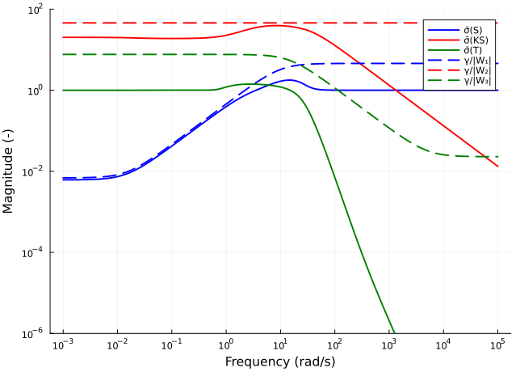

Figure 1: Several magnitude frequency responses of the closed-loop system: sensitivity $S$, complementary sensitivity $T$, and input sensitivity $KS$

```julia
using Plots
specificationplot([S, KS, T], [W₁, W₂, W₃], γ, ylabel="Magnitude (-)", title="", lw=2, nsigma=1, s_labels=["σ̄(S)", "σ̄(KS)", "σ̄(T)"], w_labels=["γ/|W₁|", "γ/|W₂|", "γ/|W₃|"],hz=false, xticks=10.0.^[-3:5...],ylims=(10^(-6),100))
```

Besides the achieved closed-loop transfer functions $\mathbf S$, $\mathbf T$ and $\mathbf{KS}$ , the figure also shows the bounds, which are given by reciprocal values of the weighting filters. There is an important implementation detail here: the bounds in the plot are not given just by $\frac{1}{|W_i(j\omega)|}$, which we may expect after having developed the conditions of robust performance, but rather by $\frac{\gamma}{|W_i(j\omega)|}$.

The time responses to steps in the reference value of the two angles are shown in Fig. 2.

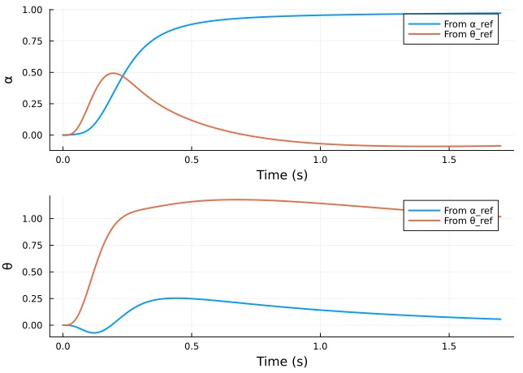

Figure 2: Response of the closed-loop system to a unit step at the reference values of the two angles

```julia
step_response = step(T)
plot(step_response, title="", xlabel="Time (s)", ylabel=["α" "θ"], lw=2, label=["From α_ref" "From α_ref" "From θ_ref" "From θ_ref"], legend=:topright)
```

We can observe in Fig. 2 decent tracking of step changes in the two angles. But we can also see some cross-coupling – it is up to us to decide whether or not it is acceptable.

Admittedly, in this section we have provided no details regarding the methods used to solved the problem of minimizing the $\mathcal H_\infty$ norm of the mixed sensitivity function; we relied on the availability of dedicated software tools. But in the next section we will have a look under the hood of these solvers. It turns out that the mixed sensitivity problem is just a special case of the general $\mathcal H_\infty$ optimal control problem, and that is why we are going to discuss it next.

Back to top

## References

[1]

M. Safonov, A. Laub, and G. Hartmann, “Feedback properties of multivariable systems: The role and use of the return difference matrix,” *IEEE Transactions on Automatic Control*, vol. 26, no. 1, pp. 47–65, Feb. 1981, doi: 10.1109/TAC.1981.1102566.